```r
options(OutDec = ".")
set.seed(sample(1:10000, 1))

# Aleatorización del contexto
contextos <- c("canal de deportes", "plataforma de streaming", "revista deportiva",
               "portal web deportivo", "aplicación móvil", "blog de fútbol")
contexto <- sample(contextos, 1)

competiciones <- c("Champions League", "Copa del Mundo", "Liga Europa",
                   "Copa América", "Eurocopa", "Copa Libertadores")
competicion <- sample(competiciones, 1)

terminos_usuarios <- c("suscriptores", "seguidores", "usuarios", "miembros", "aficionados")
termino_usuarios <- sample(terminos_usuarios, 1)

# Aleatorización de términos para encuesta
terminos_encuesta <- c("encuesta", "sondeo", "consulta", "estudio", "investigación")
termino_encuesta <- sample(terminos_encuesta, 1)

# Equipos aleatorios
equipos_disponibles <- c("Manchester City", "FC Barcelona", "Real Madrid", "Liverpool",
                        "Bayern de Múnich", "Paris Saint-Germain", "Chelsea",
                        "Manchester United", "Arsenal", "Juventus", "AC Milan",
                        "Atlético de Madrid", "Borussia Dortmund", "Ajax", "Benfica")

equipos_seleccionados <- sample(equipos_disponibles, 5)
equipo1 <- equipos_seleccionados[1]
equipo2 <- equipos_seleccionados[2]
equipo3 <- equipos_seleccionados[3]
equipo4 <- equipos_seleccionados[4]
equipo5 <- equipos_seleccionados[5]

# Población y muestra
poblacion_total <- sample(c(30000, 40000, 50000, 60000, 75000, 80000, 100000), 1)
tamano_muestra <- sample(c(80, 90, 100, 110, 120, 130, 140, 150), 1)

# Generar valores para el gráfico que sumen exactamente el tamaño de muestra
generar_valores_coherentes <- function(total) {
  # Definir rangos apropiados basados en el total
  min_valor <- max(8, round(total * 0.08))  # Mínimo 8% del total
  max_valor <- min(40, round(total * 0.35)) # Máximo 35% del total

  # MÉTODO ULTRA-SIMPLE: Distribución controlada garantizada

  # Paso 1: Calcular valor base
  valor_base <- round(total / 5)

  # Paso 2: Crear distribución inicial
  valores <- rep(valor_base, 5)
  suma_inicial <- sum(valores)
  diferencia <- total - suma_inicial

  # Paso 3: Distribuir la diferencia exacta
  if (diferencia > 0) {
    # Añadir la diferencia al primer valor
    valores[1] <- valores[1] + diferencia
  } else if (diferencia < 0) {
    # Quitar la diferencia del primer valor
    valores[1] <- valores[1] + diferencia  # diferencia es negativa
  }

  # VERIFICACIÓN CRÍTICA 1
  if (sum(valores) != total) {
    stop("ERROR CRÍTICO 1: suma = ", sum(valores), ", esperado = ", total)
  }

  # Paso 4: Verificar rangos y redistribuir si es necesario
  intentos_redistribucion <- 0
  while ((any(valores < min_valor) || any(valores > max_valor)) && intentos_redistribucion < 10) {
    intentos_redistribucion <- intentos_redistribucion + 1

    # Encontrar valores fuera de rango
    muy_altos <- which(valores > max_valor)
    muy_bajos <- which(valores < min_valor)

    # Redistribuir desde valores muy altos a valores muy bajos
    if (length(muy_altos) > 0 && length(muy_bajos) > 0) {
      idx_alto <- muy_altos[1]
      idx_bajo <- muy_bajos[1]

      # Calcular cuánto transferir
      exceso <- valores[idx_alto] - max_valor
      deficit <- min_valor - valores[idx_bajo]
      transferir <- min(exceso, deficit, 3)  # Máximo 3 unidades por vez

      valores[idx_alto] <- valores[idx_alto] - transferir
      valores[idx_bajo] <- valores[idx_bajo] + transferir

      # VERIFICACIÓN CRÍTICA 2
      if (sum(valores) != total) {
        stop("ERROR CRÍTICO 2: suma cambió a ", sum(valores), " durante redistribución")
      }
    } else {
      break  # No hay más redistribuciones posibles
    }
  }

  # Paso 5: Si aún hay valores fuera de rango, usar distribución forzada
  if (any(valores < min_valor) || any(valores > max_valor)) {
    # Distribución uniforme dentro de rangos
    valor_uniforme <- floor(total / 5)
    resto <- total %% 5

    valores <- rep(valor_uniforme, 5)

    # Distribuir resto
    for (i in 1:resto) {
      valores[i] <- valores[i] + 1
    }

    # VERIFICACIÓN CRÍTICA 3
    if (sum(valores) != total) {
      stop("ERROR CRÍTICO 3: suma incorrecta en distribución forzada")
    }
  }

  # Paso 6: Añadir variabilidad mínima SIN cambiar la suma
  if (all(valores >= min_valor) && all(valores <= max_valor)) {
    for (intento in 1:5) {  # Solo 5 intentos de variabilidad
      pos1 <- sample(1:5, 1)
      pos2 <- sample(setdiff(1:5, pos1), 1)

      # Transferir solo 1 unidad
      if (valores[pos1] - 1 >= min_valor && valores[pos2] + 1 <= max_valor) {
        valores[pos1] <- valores[pos1] - 1
        valores[pos2] <- valores[pos2] + 1

        # VERIFICACIÓN CRÍTICA 4
        if (sum(valores) != total) {
          stop("ERROR CRÍTICO 4: suma cambió durante variabilidad")
        }
      }
    }
  }

  # VERIFICACIÓN FINAL OBLIGATORIA
  if (sum(valores) != total) {
    stop("ERROR FINAL: suma = ", sum(valores), ", esperado = ", total)
  }

  return(valores)
}

valores_equipos <- generar_valores_coherentes(tamano_muestra)

# Ordenar equipos y valores para que el primer equipo tenga el valor más alto
idx_max <- which.max(valores_equipos)
if (idx_max != 1) {
  # Intercambiar valores
  temp_valor <- valores_equipos[1]
  valores_equipos[1] <- valores_equipos[idx_max]
  valores_equipos[idx_max] <- temp_valor

  # Intercambiar equipos
  temp_equipo <- equipos_seleccionados[1]
  equipos_seleccionados[1] <- equipos_seleccionados[idx_max]
  equipos_seleccionados[idx_max] <- temp_equipo
}

# Asignar variables individuales DESPUÉS del ordenamiento
valor1 <- valores_equipos[1]
valor2 <- valores_equipos[2]
valor3 <- valores_equipos[3]
valor4 <- valores_equipos[4]
valor5 <- valores_equipos[5]

equipo1 <- equipos_seleccionados[1]
equipo2 <- equipos_seleccionados[2]
equipo3 <- equipos_seleccionados[3]
equipo4 <- equipos_seleccionados[4]
equipo5 <- equipos_seleccionados[5]

# Validaciones matemáticas robustas
# Verificar que los valores suman exactamente el tamaño de muestra
if (sum(valores_equipos) != tamano_muestra) {
  stop("Error: Los valores no suman el tamaño de muestra. Suma: ", sum(valores_equipos),
       ", Esperado: ", tamano_muestra)
}

# Verificar rangos apropiados
min_esperado <- max(8, round(tamano_muestra * 0.08))
max_esperado <- min(40, round(tamano_muestra * 0.35))
if (!all(valores_equipos >= min_esperado) || !all(valores_equipos <= max_esperado)) {
  stop("Error: Algunos valores están fuera del rango esperado [", min_esperado, ", ", max_esperado, "]")
}

# Verificar que hay variabilidad
if (length(unique(valores_equipos)) < 2) {
  stop("Error: No hay suficiente variabilidad en los valores")
}

# Verificar que todos los valores son positivos
if (!all(valores_equipos > 0)) {
  stop("Error: Algunos valores no son positivos")
}

# Verificar que ningún equipo domina excesivamente
if (max(valores_equipos) > tamano_muestra * 0.4) {
  stop("Error: Un equipo tiene demasiados votos (>40% del total)")
}

# Colores para el gráfico
colores <- c("#2E8B57", "#4682B4", "#CD853F", "#9370DB", "#DC143C")

# Generar opciones de respuesta
# La respuesta correcta es sobre la proporción del equipo con más votos
proporcion_correcta <- round(valor1 / tamano_muestra * 100)
respuesta_correcta <- paste0("alrededor de ", valor1, " de cada ", tamano_muestra, " ",
                            termino_usuarios, " del ", contexto, " da por favorito al ", equipo1, ".")

# Distractores plausibles
distractor1 <- paste0("alrededor de ", valor1, " de cada ", poblacion_total, " ",
                     termino_usuarios, " del ", contexto, " da por favorito al ", equipo1, ".")

distractor2 <- paste0("ninguno de los ", poblacion_total, " ", termino_usuarios,
                     " del ", contexto, " da por favorito al ",
                     sample(setdiff(equipos_disponibles, equipos_seleccionados), 1), ".")

distractor3 <- paste0("sólo ", tamano_muestra, " de los ", poblacion_total, " ",
                     termino_usuarios, " del ", contexto,
                     " tienen preferencia por un equipo para ganar la ", competicion, ".")

# Crear vector de opciones y mezclar
opciones <- c(respuesta_correcta, distractor1, distractor2, distractor3)
opciones_mezcladas <- sample(opciones)
indice_correcto <- which(opciones_mezcladas == respuesta_correcta)

# Vector de solución para r-exams
solucion <- rep(0, 4)
solucion[indice_correcto] <- 1
```

```r
options(OutDec = ".")

# Código Python para generar el gráfico de barras horizontal
codigo_python <- paste0("
import matplotlib
matplotlib.use('Agg')
import matplotlib.pyplot as plt
import numpy as np

# Datos para el gráfico
equipos = ['", equipo1, "', '", equipo2, "', '", equipo3, "', '", equipo4, "', '", equipo5, "']
valores = [", valor1, ", ", valor2, ", ", valor3, ", ", valor4, ", ", valor5, "]
colores_grafico = ['", colores[1], "', '", colores[2], "', '", colores[3], "', '", colores[4], "', '", colores[5], "']

# Crear figura
fig, ax = plt.subplots(figsize=(8, 6))

# Crear gráfico de barras horizontal
y_pos = np.arange(len(equipos))
barras = ax.barh(y_pos, valores, color=colores_grafico, edgecolor='white', linewidth=1)

# Configurar etiquetas y título
ax.set_yticks(y_pos)
ax.set_yticklabels(equipos, fontsize=10, fontweight='bold')
ax.set_xlabel('Número de ", termino_usuarios, "', fontsize=12, fontweight='bold')
ax.set_title('Equipos favoritos para ganar la ", competicion, "', fontsize=14, fontweight='bold', pad=20)

# Añadir valores en las barras
for i, (barra, valor) in enumerate(zip(barras, valores)):
    width = barra.get_width()
    ax.text(width + 0.5, barra.get_y() + barra.get_height()/2,
            str(valor), ha='left', va='center', fontweight='bold', fontsize=10)

# Configurar límites del eje x
ax.set_xlim(0, max(valores) + 5)

# Añadir grilla sutil
ax.grid(axis='x', alpha=0.3, linestyle='--')
ax.set_axisbelow(True)

# Ajustar diseño
plt.tight_layout()

# Guardar en múltiples formatos
plt.savefig('grafico_barras.png', dpi=150, bbox_inches='tight',
           transparent=True, format='png')
plt.savefig('grafico_barras.pdf', dpi=150, bbox_inches='tight',
           transparent=True, format='pdf')
plt.close()
")

# Ejecutar código Python
py_run_string(codigo_python)
```

# Question

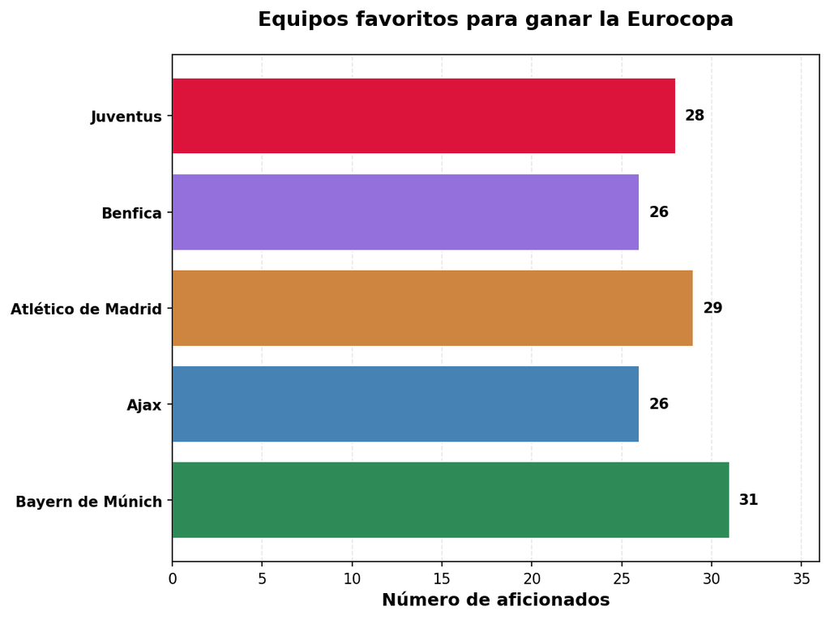

De acuerdo con los datos obtenidos en el estudio, es correcto afirmar que

## Answerlist

- alrededor de 31 de cada 30000 aficionados del plataforma de streaming da por favorito al Bayern de Múnich.
- ninguno de los 30000 aficionados del plataforma de streaming da por favorito al Arsenal.
- sólo 140 de los 30000 aficionados del plataforma de streaming tienen preferencia por un equipo para ganar la Eurocopa.
- alrededor de 31 de cada 140 aficionados del plataforma de streaming da por favorito al Bayern de Múnich.

# Solution

Para resolver este problema, necesitamos interpretar correctamente los datos del gráfico de barras y entender la diferencia entre muestra y población total.

### Paso 3: Analizar cada opción

**Opción correcta**: “alrededor de 31 de cada 140 aficionados del plataforma de streaming da por favorito al Bayern de Múnich.” Esta opción es correcta porque interpreta adecuadamente que 31 de cada 140 aficionados **de la muestra** prefieren al Bayern de Múnich. Esto representa una proporción del 22.1% en la muestra.

### Paso 4: Verificación matemática

En la muestra de 140 aficionados:

- Bayern de Múnich: 31 aficionados (22.1%)
- Ajax: 26 aficionados (18.6%)
- Atlético de Madrid: 29 aficionados (20.7%)
- Benfica: 26 aficionados (18.6%)
- Juventus: 28 aficionados (20%)

Total: 140 aficionados = 140 aficionados ✓

### Conclusión

La respuesta correcta interpreta adecuadamente que los datos del gráfico se refieren a la muestra de 140 aficionados, no a la población total.

## Answerlist

- Falso
- Falso
- Falso
- Verdadero

# Meta-information

exname: proporciones_encuesta_deportiva extype: schoice exsolution: 0001 exshuffle: TRUE exsection: Estadística|Proporciones|Interpretación de gráficos|Muestreo